# Windows下R与Rstudio的安装

## RStudio 的安装

- 如果是已经安装过，需要选择正确的R版本： 访问 `Tools/Global Options`. 选择已安装R的版本.

[figure not shown]

- 如果没有安装，请访问 http://www.rstudio.com/ and 点击 `Desktop`.

[figure not shown]

- 选择 `DOWNLOAD RSTUDIO DESKTOP`

[figure not shown]

- Download the installer for Windows.

[figure not shown]

- Open and run the file you just downloaded `RStudio-0.9x.xxxx.exe` （版本可能会有更新）
- 选择默认设置即可

.

.

.

[figure not shown]

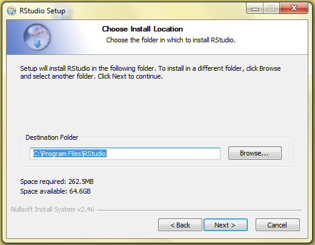

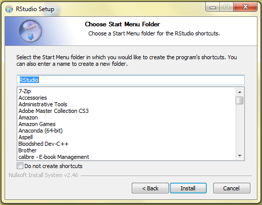

**1**

**2**

**3**

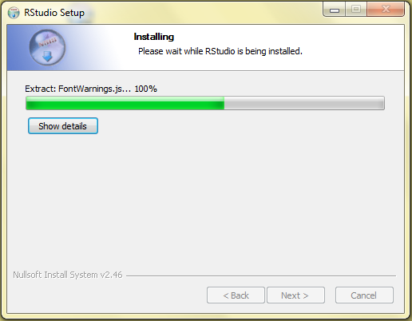

[figure not shown]

**DONE**

**4**

**5**

**6**

## 安装 devtools （可选）

- 打开 Rstudio, in the **Files/Plots/Packages/Help** panel, 选择 **Packages** 点击 **Install**

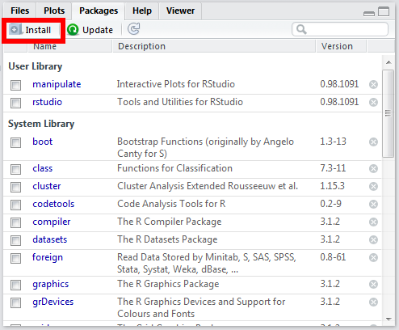

- Type `devtools` under **Packages**, make sure you spell the name of the package correctly. Then, 点击 **Install**

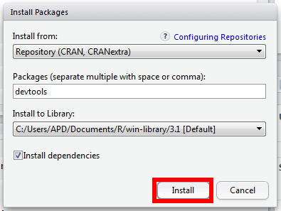

- 除了上面，可以直接运行下列语句来安装

  ```
  install.packages("devtools")
  ```